# Python Beautiful Soup Web Scraping

This is a web scraper implemented by using beautiful soup 4. This web scraper can get all the information you want from a website. I will scrape the contact information of all professors at Brandeis University as an example. First, we need to import beautiful soup 4 and urllib.request for web scraping. We also need to import pandas for building a data frame.

```python
import bs4 as bs
import urllib.request
import pandas as pd
```

Since I want to know the information about professors at Brandeis Univerity. I can search for them at this website. https://www.brandeis.edu/facultyguide/index.html

Brandeis lists professors either by schools or by last name alphabetically.

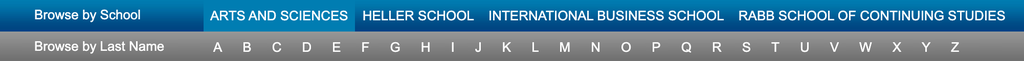

Since I want to list professors alphabetically, I need to scrape through 26 websites for each letters. It is time-consuming to click each letter's website to scrape it. We can developed a for-loop because there is a pattern for each letter's website. For example, A's website address is: https://www.brandeis.edu/facultyguide/letter.html?letter=A

We only need to change the last 'A' in the address for different letters. Therefore, we are going to build a list of 26 letters.

```python
#First, create a empty list of letters, start with A
alphabet = []
letter = 'A'

#In this for loop, the letter will be converted to number and add 1 to it to represent the next letter.
#Then, convert the number back to letter
for i in range(0, 26):
    alphabet.append(letter)
    letter = chr(ord(letter) + 1)
```

The list 'alphabet' contains all 26 letters. We then concatenate the letters with the address pattern and use beautiful soup to parse them. By inspecting the website we can see that all professors' information in 'div id='content''. Each professor's website is in a link in 'a href' tag.

We can first let the parser find this div tag, and then find all the hrefs to get professors' names and links. But these are not all the information we want, we must go to its website to search for its title and email address. Therefore, we are going to use another for loop to loop through all the professors' website and use another parser to get their title and email address. Here is an example: https://www.brandeis.edu/facultyguide/person.html?emplid=ee995cbbd5fff5456e58b19f306d13fe88f30667

[figure not shown]

From this website, we can see that the title of the professor in 'div id='title'' tag and the email address in 'div id='contact'' tag. I will scrape these information and put them into the lists.

```python
#the pattern of url
url_pattern = 'https://www.brandeis.edu/facultyguide/letter.html?letter='

#create the list of information we want
name = []
title = []
website =[]
email = []

#loop through all letters
for char in alphabet:
    #open the newly concatenated link
    sauce = urllib.request.urlopen(url_pattern+char).read()
    #set up the bs parser
    soup = bs.BeautifulSoup(sauce, 'lxml')
    tags = soup.find('div', attrs = {'id' : 'content'}).find_all('a',href=True)

    #scrape all the professors' websites in this page
    for tag in tags:
        #get names
        name.append(tag.text)
        #get website urls
        site ='https://www.brandeis.edu/facultyguide/'+tag.get('href')
        website.append(site)
        #set up another parser to scrape the url
        subsauce = urllib.request.urlopen(site).read()
        subsoup = bs.BeautifulSoup(subsauce, 'lxml')
        #get titles
        title.append(subsoup.find('div', attrs = {'id' : 'title'}).string.strip('\r\n'))
        #get email addresses. Note: some of them do not have a email address so we are going to append 'N/A'
        if subsoup.find('div', attrs = {'id' : 'contact'}).find('a', href=True) is None:
            email.append('N/A')
        else:
            email.append(subsoup.find('div', attrs = {'id' : 'contact'}).find('a', href=True).string)
```

Now, we have all 987 Brandeis professors' names, titles, websites and emails. We are going to put those lists into a dataframe and display a small snippet.

```python
scraped = pd.DataFrame({'Name':name,'Title':title,'Website':website,'Email':email},
                       columns = ['Name','Title','Website','Email'])
scraped
```

|  | Name | Title | Website | Email |
| --- | --- | --- | --- | --- |
| 0 | Abdur-Rahman, Aliyyah | Adjunct Associate Professor of English | https://www.brandeis.edu/facultyguide/person.h... | aliabdur@brandeis.edu |
| 1 | Abdurezak, Hamza | Senior Lecturer in the Brandeis Intern... | https://www.brandeis.edu/facultyguide/person.h... | abdurez@brandeis.edu |
| 2 | Abramson, Marcie F | Lecturer in Education | https://www.brandeis.edu/facultyguide/person.h... | bramson@brandeis.edu |
| 3 | Abusch, Tzvi | Rose B. and Joseph Cohen Professor of ... | https://www.brandeis.edu/facultyguide/person.h... | abusch@brandeis.edu |
| 4 | Acevedo Garcia, Dolores | Samuel F. and Rose B. Gingold Professo... | https://www.brandeis.edu/facultyguide/person.h... | dacevedo@brandeis.edu |
| ... | ... | ... | ... | ... |
| 982 | Zhang, Shuren | Scholar in the Brandeis International ... | https://www.brandeis.edu/facultyguide/person.h... | N/A |
| 983 | Zhang, Zhaojie | Instructor in the Rabb School of Conti... | https://www.brandeis.edu/facultyguide/person.h... | zhaojiezhang@brandeis.edu |
| 984 | Zhu, Mengnan | Adjunct Professor in the Brandeis Inte... | https://www.brandeis.edu/facultyguide/person.h... | cliffzhu@brandeis.edu |
| 985 | Zimmerman, Grace E. | Professor of the Practice of Marketing... | https://www.brandeis.edu/facultyguide/person.h... | gzimmerm@brandeis.edu |
| 986 | Zinner, Darren E. | Associate Professor; Associate Dean fo... | https://www.brandeis.edu/facultyguide/person.h... | dzinner@brandeis.edu |

987 rows × 4 columns